# Faxina de Dados - Base Municipal de Óbitos por Covid na base da PJF

Marcello S. Filgueiras

23 junho 2021

## Introdução

Olá caros amigos da Curso-R. Meu nome é Marcello S. Filgueiras e esse é o meu TCC para o curso de Faxina de dados.

A base escolhida trata-se de uma base de “metadados” dos óbitos de covid em Juiz de Fora, disponibilziada pela prefeitura da cidade (PJF) [aqui no seu site oficial](https://covid19.pjf.mg.gov.br/arquivos/obitos_covid19_jf.pdf).

É o mais próximo de uma base de metadados que se tem na cidade, tendo em vista que as bases do DataSus e do Estado apesar de mais detalhadas tem número *bastante inferior* ao divulgado pela prefeitura (atraso de mais de dias).

A prefeitura só divulga os números agregados totais de mortos em XLS. Inclusive, não se trata para cadia mostrando a evolução, mas apenas o último número total.

Cada um desses problemas foram resolvidos. Todos esses problemas serão explicados ao longo do código, de forma setorizada. Tentei ao máximo fazer uma seção por arquivo. No final alguns gráficos foram feitos com a base arrumada.

## 1) Lendo PDF (Importing)

### 1.1) Trazendo a base do PDF para um DF no R

Se você não abriu o PDF, por favor, abra para entender melhor o processo. O arquivo está [aqui no site da PJF](https://covid19.pjf.mg.gov.br/arquivos/obitos_covid19_jf.pdf).

```r
url <- "https://covid19.pjf.mg.gov.br/arquivos/obitos_covid19_jf.pdf"

obitos_diarios_pjf_raw <- tibble(
  texto= pdftools::pdf_text(url),
  pag= pdf_length(url))

obitos_diarios_pjf_raw %>%
  slice(1) %>%
  pull(texto)
```

```
## [1] "1.    Idoso, 70 anos, comorbidades: hipertensão arterial sistêmica e doença cardiovascular\n      crônica. Óbito em 7/04;\n2.    Idoso, 71 anos, comorbidades: diabetes, doença cardiovascular crônica, hipertensão\n      arterial. Óbito em 29/03;\n3.    Homem, 41 anos, comorbidades: doença car…
```

A estrutura do PDF original lembra a de um CSV, em que cada linha no PDF é um caso separado por delimitadores, mas está longe disso.

Para cada linha, o separador ao final de cada uma varia. As vezes é um **“;” “.”** ou até em alguns casos casos, um vazio, **""**.

Dentro de cada linha, o separador de colunas as vezes é **“.”, “,” ou apenas um espaço ""** .

O primeiro passo foi ler o PDF e **transformá-lo em um data frame**, com uso de `tibble()`. A primeira coluna `texto` é leitura de cada página do PDF. Ao lado dela, foi criada `pag`, o número de páginas do PDF para manter o controle e ajudar com alguns problemas com datas lá na frente.

(Como automatizar a colocação desse número de páginas? Sempre que o número de páginas aumenta é necessário reformar o código e aumentar aqui).

```r
obitos_diarios_pjf_raw <- tibble(
  texto= pdftools::pdf_text(url),
  pag= 1:pdf_length(url))

obitos_diarios_pjf_raw
```

```
## # A tibble: 46 x 2
##    texto                                                                     pag
##    <chr>                                                                   <int>
##  1 "1.    Idoso, 70 anos, comorbidades: hipertensão arterial sistêmica e ~     1
##  2 "26. Idosa, 83 anos. Óbito em 12/05;\n27. Idosa, 86 anos, comorbidade:~     2
##  3 "57. Idosa, 84 anos. Óbito em 01/07/2020. Comorbidades, DCC, HAS, outr~     3
##  4 "96. Idosa, 97 anos. Óbito em 20/7. Comorbidades: DCC, DNC\n97. Idoso,~     4
##  5 "135. Idoso, 70 anos. Óbito em 14/08. Comorbidade: DCC.\n136. Idosa, 9~     5
##  6 "174. Idosa, 72 anos. Óbito em 06/09. Comorbidades: DCC, HAS, DNC.\n17~     6
##  7 "212. Idoso, 86 anos. óbito em 28/9. Comorbidades: DCC, HAS;\n213. Ido~     7
##  8 "251. Idoso, 86 anos. Óbito em 16/10. Comorbidades: DCC, DNC;\n252. Id~     8
##  9 "289. Idosa, 61 anos. Óbito em 19/11. Comorbidades: DCC, obesidade;\n2~     9
## 10 "325. Idoso, 71 anos. Óbito em 27/11. Comorbidades: DCC;\n326. Idosa, ~    10
## # ... with 36 more rows
```

## 2) Mantendo a estrutura de uma observação por linha (Tidying)

### 2.1) Separando Linhas

No documento inicial, cada linha deveria ser um paciente (e quase é). Sendo assim, foi feito apenas uma separação com **“\n”** no início.

Mas nas linhas muito grandes, que passavam da margem, a mesma observação era dividida em duas linhas, tendo um **“\n”** do meio, representando duas linhas no texto sobre o mesmo caso.

Por isso, tentei optei pela separação de cada linha pelos números iniciais, que são “1.”, “2.”, “3.”, “100.” … que existem no começo. Mas **“d+\\.”**também pegava também datas que estavam separadas por pontos nas frases.

Juntando as duas coisas optei por um separador de uma quebra de linha “” acomapanhada por números iniciais, que são “1.”, “2.”, “3.”, “100.” … por isso, optei pela regex de por **“\\r\\n\d+\\.”**.

No pdf original, o mesmo código, no mesmo arquvio, o **“\r\n”** existia. Depois, *por vozes misteriosas por além*, rodando *o mesmo código, no mesmo arquivo*, não existe mais. Assim a regex da delimitação de cada linha ficou somente no “\\n\d+\\.” mesmo (e funcionou!). Não sei como o “\r” sumiu.

Assim, Separando Cada Linha do PDF que corresponde a um caso com o seguinte código:

```r
obitos_diarios_pjf_separado<- obitos_diarios_pjf_raw %>%
  mutate(texto= str_split(texto, "\\n\\d+\\. "))%>%
  unnest(texto)

obitos_diarios_pjf_separado %>%
 as_tibble()
```

```
## # A tibble: 1,743 x 2
##    texto                                                                     pag
##    <chr>                                                                   <int>
##  1 "1.    Idoso, 70 anos, comorbidades: hipertensão arterial sistêmica e ~     1
##  2 "   Idoso, 71 anos, comorbidades: diabetes, doença cardiovascular crôn~     1
##  3 "   Homem, 41 anos, comorbidades: doença cardiovascular crônica. Óbito~     1
##  4 "   Idosa, 91 anos, comorbidade: câncer e doença neurológica crônica. ~     1
##  5 "   Idoso, 84 anos, comorbidade: doença oncológica. Óbito em 23 de abr~     1
##  6 "   Idosa, 88 anos, comorbidades: hipertensão arterial sistêmica e hip~     1
##  7 "   Mulher, 55 anos, comorbidades: imunodeficiência, doença renal crôn~     1
##  8 "   Idoso, 77 anos. Óbito em 3 de maio."                                    1
##  9 "   Idosa, 77 anos, comorbidades: hipertensão arterial sistêmica e doe~     1
## 10 "  Idosa, 87 anos, comorbidades: doença cardiovascular crônica e doenç~     1
## # ... with 1,733 more rows
```

Assim, resolvemos o problema 1, tendo um df em um objeto de “fácil manuseio”, e mantivemos a estrutura de uma observação por por linha, o problema 2. Agora, vamos à luta: separar as variáveis dentro da string, para depois, padronizá-las.

## 3) Separando uma váriavel por coluna (Tidying)

No PDF original, teríamos 4 colunas, `c("genero", "idade", "data_do_obito" e "comorbidades")`. Mas na coluna gênero, temos duas variáveis: o `"gênero" e "faixa etária"`, em que o valor “idoso” explicita ao mesmo tempo que é masculino e tem mais de 60 anos.

A ideia original era separar todas essas colunas com um delimitador,como um read_delim, mas isso não é possível.

Ora estamos com a ordem de `c( "genero", "idade", "data_do_obito" e "comorbidades")`. Ora estamos com a ordem de `c( "genero", "idade", "comorbidades" e "data_do_obito")`. Temos inclusive um caso de 5 colunas: `c( faixa etária, genero, idade, data_do_obito e comorbidade"`, no exemplo `"idoso, masculino, 88 anos. óbito em 05/07/2020. comorbidades:dcc, etc."`.

Portanto, como primeiro passo para transformar isso em uma tabela tidy:

Vamos separar uma variável por coluna, buscando cada uma dessas informações com funções `stringr` e `tidyr::separate()`.

Para saber como buscar, precisamos saber os valores que cada variável está colocada. Em cada variável temos os seguintes valores:

- Gênero: Não só dois, temos 6 gêneros: “idoso”, “idosa”, “masculino”, “feminino”, “homem” e “mulher”. É sempre a primeira variável da linha, o que dá para separar facilmente com uma vírgula portanto.
- Idade: “dd anos” sempre os primeiros algarismos da linha.
- Data: temos dd/mm/aaaa, dd/mm/aa, dd/mm, “dd do mes” e incríveis “ultimo domingo, 22”. Busquei dessa forma cada um desses formatos na string.
- Comorbidade: Se não tem nenhuma, está “Sem Comorbidade Relatada” ou NA. Se tem, começa com “Comorbidade: nome da doença…” ou “Fator de Risco: Nome da Doença”. Mandei dessa forma, buscar tudo que vem depois de comorbidade, com alguns detalhes no meio.

A coluna texto foi feita para buscar cada uma dessas variáveis, e até para manter o controle do que estava sendo feito

Assim foi feito o código buscando cada variável abaixo:

### 3.1) Separando Colunas dentro da String

```r
obitos_diarios_pjf_clean<- obitos_diarios_pjf_separado %>%
  #Limpando os algarismos que começam no inicio de cada linha e são seguidos por  um"." . "1304 não tinha ponto e ficou para trás teve que ser feito manualmente. Aproveitando para tudo no low para facilitar regex;
  mutate(texto=str_remove(texto, "^\\d+\\.|1304") %>%
           str_to_lower(),
  #Retirando alguns espaços do PDF que restaram na linha separada
         texto= str_remove_all(texto, "\\r\\n") %>%
           str_squish()) %>%
  #o gênero está na ordem, então aqui um separate funciona.
  tidyr::separate(col=texto,
                  into= c("genero", "texto"),
                  sep = ",|\\.| ",
                  extra= "merge")%>%
  # Tentando buscar idade com separate(). Vai dar problema no caso de uma coluna a mais e casos de natimortos. Fiz para verificar.
        #mutate(texto= str_trim(texto)) %>%
        #tidyr::separate(col=texto,
        #into= c("idade", "texto"),
        #sep = ",|\\.| ",
        #extra= "merge")
  # Portanto, busquei Idade com str_extract e padronizando a idade de bebês;
  mutate(idade = case_when(
    genero== "natimorto" | str_detect(texto,"natimorto") ~ "0", # ( idade de bebês = 0 ) Triste =/
    str_detect(texto,"01 dia") ~ "0",  # (idade de bebês = 0)   =/ Triste
    TRUE ~ str_extract(texto, "\\d+"))%>%  # Depois disso, extraí todos os primeiros algarismos. Como a idade está na frente, não há problema.
      as.numeric(), #com todas idades completas em formato character, já transformei para numeric.
    #buscando data do obito em varios formatos.
    data_obito = str_extract(texto, paste("\\d+/\\d+(/\\d+)*", #dd/mm e dd/mm/yy e dd/mm/yyyy
                                          "\\d{4,4}",          #ddmm (sem separador)
                                          "\\d{1,2} de \\w*",  #dia em número e mês por extenso
                                          "morreu.*\\d+",      #"morreu no último domingo,dd"
                                          sep = "|")),
    #Buscando comorbidades
    comorbidade= case_when(
      str_detect(texto,"sem comorbidade") ~ "sem comorbidade", #buscando o que nao tem comorbidade
      TRUE ~ str_extract(texto, "comorbidade(s)*.+|fator de risco(s)*.+")), #buscando tudo que vem depois de "comorbidades" ou "fator de risco"
      #Em algumas linhas, a ordem é "data_do_obito","comorbidades" e nada vem depois.Portanto, essa regex, nessas linhas, pega somente as comorbidades, porque comorbidade está por último.
      #Entretanto, algumas linhas estão na ordem "comorbidades", "data do óbito". Nesses casos, mandei tirar tudo que vem depois de "óbito", para ficar somente comorbidades.
    comorbidade = str_remove(comorbidade, paste("[oó]bito.+",
                                                "óbito$",
                                                sep= "|")) ,
    #tendo certeza que tudo nessa coluna é comorbidade, mandei tirar as iniciais da coluna. Aproveitei para limpar um str_squish no final
    comorbidade = str_remove(comorbidade, "comorbidade(s)*(:|,)|comorbidade(s)*/fator de risco:|fator de risco:") %>%
      str_squish(),
    #Lidandos Falsos NA. Não indicavam o separador "comorbidade:" mas tinham o separador depois. Vieram somente a doença. Por isso vieram nulos, mas não eram NAs.
    #Fiz na Mão
    comorbidade = ifelse(is.na(comorbidade),
                         str_extract(texto, "has, dnc, ca|dcc, dm|imunodeficiência, outra pneumopatia crônica"),
                         as.character(comorbidade)),
    #Retirando finais de linhas que ainda continham separadores
    comorbidade = str_remove(comorbidade, "(\\.|,|;)$"),
    #Por fim, criando a coluna faixa etária, muito mais delimitada que "idoso" ou "não idoso"
    faixa_etaria = cut(idade,
                            breaks =  c(-1,20,40,60,80,101),
                            labels = c("Menos de 20", "20 a 40", "40 a 60",
                                       "60 a 80", "Mais de 80")))
```

Portanto, resolvemos o terceiro problema, temos uma variável por coluna. Vamos agora padronizá-las.

## 4) Padronizando Valores das Variáveis em cada coluna

De posse de uma variável por coluna, o próximo passo é padronizar a forma com que os valores aparecem, no campo Comorbidade, Gênero e nas Datas, bem como colocar na classe mais adequada do R.

### 4.1) Padronizando Gênero e Comorbidades

### a) Problemas na Comorbidade

Na coluna `comorbidade`temos doenças em várias abreviações e vários nomes completos.

Dentro da possibilidades, busquei colocar tudo da mesma doença, mas que está com nomes diferente, no mesmo valor dentro da variável.

Porém falta padronização quanto ao nível de especialização, algumas doenças estão somente nos grandes grupos, como “câncer”, mas também temos as especificadas “câncer de mama”, “prostata”, “utero” e etc. Temos vários desses problemas no grande grupos de doença cardiovasculares crônicas e suas várias especializações.

Como a necessidade de mais especialização ou menos varia com o objetivo, optei por deixar tais casos na base, para se for de interesse, agrupá-las.

Não é possível fazer um `unnest()` agora por ausência de padronização na delimitação para verificar o antes e depois, mas no final, é possível verificar essa ação.

### b) Problemas no Gênero

Na coluna `genero` temos dois gêneros com várias caligrafias diferentes para “masculino” e “feminino”, como você pode ver abaixo.

```r
table(obitos_diarios_pjf_clean$genero)
```

```
##
##  feminina  feminino     homem     idosa     idoso     isosa     isoso masculino
##         1       158         3       651       664         1         1       260
##    mulher natimorto
##         2         2
```

Assim, esses dois vetores foram criados para usar na hora de padronizar as colunas de `genero`.

```r
genero_feminino <- c( "feminino", "feminina", "idosa", "isosa", "mulher")
genero_masculino <- c( "homem", "idoso", "isoso", "masculino", "natimorto")
```

No código abaixo tentei enfrentar esses dois problemas.

A `genero` foi fácil, a coluna `comorbidade` deu mais trabalho. Por isso, fiz duas colunas: uma original `comorbidade`, para manter controle, fazendo as alterações na coluna `comorbidades`.

```r
obitos_diarios_pjf_tidy_gen_com <- obitos_diarios_pjf_clean %>%
  #Com as variáveis já separadas, podemos retirar a coluna original do texto.
  select(!texto) %>%
  #1º Passo - Padronizando GÊNERO
  mutate(genero= case_when(
    genero %in% genero_feminino ~ "feminino",
    genero %in% genero_masculino ~ "masculino",
    TRUE ~ as.character(genero)),
  #2º Passo - Padronizando COMORBIDADES.
  #Criei coluna comorbidade (original) e comorbidades (modificada) para ter controle do que fazia
  #Acho que as colunas são autoexplicativas de qual conteúdo da mesma variável doença, despadronizada, passada doença, padronizada
    comorbidades= str_remove(comorbidade, "severa descompensada e não tratada|;l"), #;l foi um caso sem padronização no final
    comorbidades= str_replace_all(comorbidades, "drc\\b|irc", "doença renal crônica"),
    comorbidades= str_replace_all(comorbidades, "dialítico|dial[íi]tica", "dialitico"),
    comorbidades= str_replace_all(comorbidades, "dc(c)*", "doença cardiovascular crônica"),
    comorbidades= str_replace_all(comorbidades, "dm|diabetes mel{1,2}itus", "diabetes"),
    comorbidades= str_replace_all(comorbidades, "has|hás|hs|had\\b|hipertensão arterial$", "hipertensão arterial sistêmica"),
    comorbidades= str_replace_all(comorbidades, "dpoc", "doença pulmonar obstrutiva crônica"),
    comorbidades= str_replace_all(comorbidades, "\\b[cç]a\\b( de)*|paciente oncológico|doença oncológica", "câncer"),
    comorbidades= str_replace_all(comorbidades, "câncer útero|útero","câncer útero"),
    comorbidades= str_replace_all(comorbidades, "dnc", "doença neurológica crônica"),
    comorbidades= str_replace_all(comorbidades, "dhc", "doença hepática crônica"),
    comorbidades= str_replace_all(comorbidades, "outra pneumopatia", "pneumopatia"),
    comorbidades= str_replace_all(comorbidades, "iam", "infarto agudo do miocárdio"),
    comorbidades= str_replace_all(comorbidades, "\\bave", "acidente vascular encefálico"),
    comorbidades= str_replace_all(comorbidades, "marcapasso","marca-passo"),
    comorbidades= str_replace_all(comorbidades, "imunosupressão","imunossupressão"),
    comorbidades= str_replace_all(comorbidades, "\\bfa\\b", "fibrilação atrial"),
    comorbidades= str_replace_all(comorbidades, "\\btu\\b", "tumor"),
    comorbidades= str_replace_all(comorbidades, "\\bave\\b", "acidente vascular encefálico"),
    comorbidades= str_replace_all(comorbidades, "cardiopata", "cardiopatia"),
    comorbidades= str_replace_all(comorbidades, "histórico de avc", "acidente vascular cerebral prévio"),
    comorbidades= str_replace_all(comorbidades, "avc", "acidente vascular cerebral"),
    comorbidades= str_replace_all(comorbidades, "dvc", "doença venosa crônica"),
    comorbidades= str_replace_all(comorbidades, "tep", "tromboembolismo pulmonar"),
    comorbidades= str_replace_all(comorbidades, "tb( pulmonar)*", "tuberculose pulmonar"),
    comorbidades= str_replace_all(comorbidades, "etilismo", "etilista"),
    comorbidades= str_replace_all(comorbidades, "hpb", "hiperplasia prostática benigna"),
    comorbidades= str_replace_all(comorbidades, "usuário de droga", "drogadição"),
    comorbidades= str_replace_all(comorbidades, "puérpera","puerpério"),
    comorbidades= str_replace_all(comorbidades, "tce","traumatismo cranioencefálico"),
    comorbidades= str_replace_all(comorbidades, "imunosupressão","imunossupressão"),
    comorbidades= str_replace_all(comorbidades, "pti","púrpura trombocitopênica idiopática"),
    comorbidades= str_replace_all(comorbidades, "drge","doença do refluxo esofágico"),
    comorbidades= str_replace_all(comorbidades, "eplepsia|convulsão|crise convulsiva","epilepsia"),
    comorbidades= str_replace_all(comorbidades, "transtorno bipolar","bipolar"),
    comorbidades= str_replace_all(comorbidades, "transtorno depressivo","depressão"),
    comorbidades= str_replace_all(comorbidades, "síndrome demência","demência"),
    comorbidades= str_replace_all(comorbidades, "transplantado","transplante"),
    comorbidades= str_replace_all(comorbidades, "\\bic(c)*\\b","insuficiência cardiáca"),
    comorbidades= str_replace_all(comorbidades, "dac|coronariopata|coranopata","doença arterial coronariana"),
    comorbidades= str_replace_all(comorbidades, "da,","doença arterial coronariana,"),#se colocasse da(c)* na linha acima, quando fosse pegar dac, só pegaria dac, por isso optei por uma nova linha
    comorbidades= str_replace_all(comorbidades, "deficicência","deficiência"),
    comorbidades= str_replace_all(comorbidades, "transplantado","transplante"),
    comorbidades= str_replace_all(comorbidades, "dsp","intoxicação diarreica por molusco"),
    comorbidades= str_replace_all(comorbidades, "dlp|dislepidemia","dislipidemia"),
    comorbidades= str_replace_all(comorbidades,
                                  paste("hiperplasia benigna próstata",
                                        "hiperplasia prostática benigna",
                                        sep= "|"),
                                  "hiperplasia de próstata"),
    #arrumando delimitadores dentro da coluna comorbidades " e " e "," por "/"
    comorbidades= str_replace_all(comorbidades, " e |,", "/"),
    #a intenção era retirar tudo que estava dentro de parentêses geralmente a "sigla(explicação da sigla)"
      # mas comorbidades= str_remove_all(comorbidades, "\\(.+\\)"), quando havia mais de dois parenteses por linhas, removia tudo entre elas.
    # ex: "doença cardiovascular crônica (dcc), diabetes melitus (dm)" retivara não só cada grupo desse, mas tudo como uma regex "(dcc.*dm)"
    # Assim, fiz na mão, retirando cada um dos casos entre parênteses que apareceram:
    comorbidades= str_remove_all(comorbidades, paste("\\(diabetes\\)",
                                                     "\\(doença cardiovascular crônica\\)",
                                                     "\\(doença pulmonar obstrutiva crônica\\)",
                                                     "\\(hipertensão arterial sistêmica\\)",
                                                     "\\(alzheimer\\)",
                                                     "\\(doença renal crônica\\)",
                                                     "\\(doença neurológica crônica\\)",
                                                     sep= "|")),
    #Todas as Comorbidades estão separadas por "," prontas para sofrerem unnest. Finalizando, retirando espaços.
    comorbidades = str_squish(comorbidades),
  #um caso em que não havia separado nenhum, foi necessário colocar na mão
    comorbidades = str_replace(comorbidades,
                             pattern = "doença cardiovascular crônica marca-passo",
                             replacement = "doença cardiovascular crônica/marca-passo"),
  #retirando espaços depois de barras, str squish nao pegou esse caso
    comorbidades= str_replace_all(comorbidades, " / | /|/ ", "/"),
    #Arrumando NA e Sem Comorbidades
    comorbidades = str_replace(comorbidades, "comorbidades", "sem comorbidade"),
    comorbidades = tidyr::replace_na(comorbidades, "sem comorbidade"))
```

**Coluna Gênero Tidy!** Valores da variável gênero de uma só forma.

Antes:

```r
table(obitos_diarios_pjf_clean$genero)
```

```
##
##  feminina  feminino     homem     idosa     idoso     isosa     isoso masculino
##         1       158         3       651       664         1         1       260
##    mulher natimorto
##         2         2
```

Depois:

```r
table(obitos_diarios_pjf_tidy_gen_com$genero)
```

```
##
##  feminino masculino
##       813       930
```

**Coluna Comorbidades Tidy!**

Ela tem todas as variáveis padronizadas e separadas pelo mesmo delimitador “/”. Dando Unnest nas comorbidades para verificar padronização dessa coluna:

```r
obitos_diarios_pjf_tidy_comorbidade_separado <- obitos_diarios_pjf_tidy_gen_com %>%
  mutate(comorbidades= str_split(comorbidades, "/")) %>%
  unnest(comorbidades)

table(obitos_diarios_pjf_tidy_comorbidade_separado$comorbidades)
```

```
##
##                      abscesso cerebral             acidente vascular cerebral
##                                      1                                      4
##      acidente vascular cerebral prévio           acidente vascular encefálico
##                                      2                                      7
##    acidente vascular encefálico prévio                              alzheimer
##                                      4                                      7
##                               amaurose                     amaurose bilateral
##                                      1                                      1
##                                 anemia                              aneurisma
##                                      2                                      1
##           aneurisma de aorta abdominal                         apneia do sono
##                                      1                                      1
##                               arritmia                      arterite temporal
##                                      5                                      1
##                                artrite                     artrite reumatoide
##                                      2                                      3
##                   artrite soronegativo                                artrose
##                                      1                                      1
##                                   asma                                autismo
##                                     38                                      1
##                      bariátrica previa                                 bexiga
##                                      1                                      1
##                              bronquite                             cadeirante
##                                      7                                      1
##                                 câncer                          câncer bexiga
##                                     31                                      2
##                        câncer cerebral                      câncer endométrio
##                                      1                                      1
##                         câncer esôfago                          câncer língua
##                                      2                                      1
##                            câncer mama                     câncer metastático
##                                      4                                      1
##                           câncer pelve                        câncer próstata
##                                      1                                      5
##                          câncer pulmão                           câncer útero
##                                      4                                      2
##                            cardiopatia                               cegueira
##                                      4                                      1
##                   deficiência auditiva                               demência
```

[output cut: 106 more lines]

```
##                                     13                                      1
##                   transplante hepático                      transplante renal
##                                      1                                      2
##           traumatismo cranioencefálico               tromboembolismo pulmonar
##                                      1                                      2
##               trombose venosa profunda                   tuberculose pulmonar
##                                      1                                      2
##                         tumor cerebral                    tumor de snc prévio
##                                      3                                      1
##                        tumor intestino                             tup em hie
##                                      1                                      1
##                             varicocele                           vasculopatia
##                                      1                                      2
##                vasculopatia periférica
##                                      1
```

Como dito acima, dentro das possibilidades, procurei manter as mesmas doenças padronizadas, tentando mudar a que estava com nomes diferentes, mantendo a opção de detalhamento de algumas bases. Única sigla que não consegui achar o significado foi “tup em hie”.

### 4.2) Padronizando Data do óbito

Na coluna `data_obito`, temos a data efetiva do óbito (não da notificação) em vários padrões:

Em algarismos, temos “dd/mm/yy”, “dd/mm/yyyy”, “dd/mm”, “d/mm”, “dd/m” e “ddmm”. Por extenso, “dd de mes por extenso” e incríveis “morreu no último domingo, dd”.

A meta é passar tudo para yyyy-mm-dd como classe de “date” dentro R.

Primeiro, a ideia é: a) passar tudo extenso para númerico; b) arrumar o númerico; c) lidar com números faltantes; d) para depois, juntar tudo no formato date.

#### a) Passando as datas que estão escritas por extenso para número.

```r
obitos_diarios_pjf_tidy_datas_extenso<- obitos_diarios_pjf_tidy_gen_com %>%
  mutate(
    data_obito= stringr::str_replace(data_obito, "janeiro", "01"),
    data_obito=stringr::str_replace(data_obito , "fevereiro", "02"),
    data_obito=stringr::str_replace(data_obito , "março", "03"),
    data_obito=stringr::str_replace(data_obito , "abril", "04"),
    data_obito=stringr::str_replace(data_obito , "maio", "05"),
    data_obito=stringr::str_replace(data_obito , "junho", "06"),
    data_obito=stringr::str_replace(data_obito , "julho", "07"),
    data_obito=stringr::str_replace(data_obito , "agosto", "08"),
    data_obito=stringr::str_replace(data_obito , "setembro", "09"),
    data_obito=stringr::str_replace(data_obito , "outubro", "10"),
    data_obito=stringr::str_replace(data_obito , "novembro", "11"),
    data_obito=stringr::str_replace(data_obito , "dezembro", "12"),
    data_obito=stringr::str_replace(data_obito , " de ", "/"),
    # Tratando ultimo caso por extenso e aproveitando para arrumar uns de character
    data_obito= case_when(
      str_detect(data_obito, "/21\\b") ~ str_replace(data_obito,"/21\\b","/2021"), #Aproveitei para passar /yy para /yyyy
      str_detect(data_obito, "/20\\b") ~ str_replace(data_obito,"/20\\b","/2020"),
      str_detect(data_obito, "morreu") ~ str_extract(data_obito, "\\d+"), # retirando o ultimo caso por extenso, de "morreu no ultimo domingo, dd".
      str_detect(data_obito, "^\\d{4,4}") ~ paste(str_extract(data_obito,"\\d{2,2}"),
                                                  "/",
                                                  str_extract(data_obito, "\\d{2,2}\\b")),
      # Padronizando casos de datas ddmm sem parentes ou qualquer delimitandor entre.
      #Se encontrar quatro números, contínuos, no início da coluna, sem delimitador entre eles,
      # faça um paste colocando um delimitardor entre os dois primeiros e os dois últimos números
      TRUE ~ data_obito))
```

#### b & c) Padronizando datas númericos e faltantes

Casos de “/yy” e sem delimitador entre datas foram arrumadas logo no chunk acima, a partir da 15 linha,

Entetanto, ainda temos alguns problemas com datas em algarismos, que ainda estavam despadronizadas (d/mm/aaaa ou dd/m/aaaa).

Junto disso, temos problemas de datas faltantes, com linhas sem o respectivo ano, registrados como NA (dd/mm), e até mesmo casos de somente dias (dd), graças aos casos de “último domingo”.

Assim, separei as Datas em três colunas difrentes “dia”, “mes”, “ano” para facilitar na faxina. Com todos os numeros arrumados, juntei tudo com `tidyr::unite()` na lógica abaixo.

O PDF é atualizado todo dia e pelo menos, ele vai em “ordem” do que seria a data da notificação. Então, dá pra saber que algumas áreas do documento vão ter necessariamente datas em algumas épocas.

```r
obitos_diarios_pjf_tidy_datas_numero<- obitos_diarios_pjf_tidy_datas_extenso %>%
  mutate( data_obito = str_split(data_obito, "/")) %>%
  unnest_wider(data_obito) %>%
  rename("dia"= "...1", "mes"= "...2", "ano" = "...3" ) %>%
  #arrumando meses e dias com apenas um algarismo (dd/m/yyyy, d/mm/yyyy e d/m/yyyy) #Tentei com across não funcionou
  mutate(dia = case_when(
    str_length(dia) == 1 ~ paste(0, dia, sep= ""),
    TRUE ~ as.character(dia)),
    mes = case_when(
      str_length(mes) == 1 ~ paste(0, mes, sep= ""),
      is.na(mes) & pag == 9 ~ "11",
      TRUE ~ as.character(mes)),
    mes= str_replace(mes,"00","01"),
    ano = case_when(#arrumando anos faltantes com auxílio da pagina do documento e o mês que ela se encontra
      pag == 31 & dia == 23 ~ str_replace(ano, "2021","2020"), #um caso em que a data está  23/12/2021.
      ano == "2020" ~ as.character(ano), #Como a ordem importa no case_when, apenas para não acionar nos casos que já estão completos
      ano == "2021" ~ as.character(ano), #Como a ordem importa no case_when, apenas para não acionar nos casos que já estão completos
      pag <= 13 ~ "2020", #todas as linhas acima da página 13 são 2020
      pag >= 24 ~ "2021", #todas as linhas abaixo da página 24 são 2021
      pag >= 14 & pag <= 23 & str_detect(mes, "12") ~ "2020", #o que estiver entre 14 e 23 e for mês 12 é 2020
      pag >= 14 & pag <= 23 & str_detect(mes, "01|02|03") ~ "2021" #o que estiver entre 14 e 23 e for mês 1,2 ou 3 é 2021
    ))
```

#### d) Unindo Datas

Ultimos passos antes do tidy final. Unindo para transformar datas character em dates, com lubridate

```r
obitos_diarios_pjf_tidy <- obitos_diarios_pjf_tidy_datas_numero %>%
  mutate(across(c(dia:ano), str_squish)) %>% #Ultima Limpada antes da unida, mas across não funcionou muito bem, ora funcionava ora não
  unite("data_obito", dia:ano, sep="-") %>% #Unindo as colunas dia, mes e ano em uma só
  mutate(data_obito=lubridate::dmy(data_obito)) %>% #Transformando em objeto data
  #mutate(data_obito = readr::parse_date(data_obito, format = "%d/%m/%Y")) %>%
  select(!comorbidade) %>% #retirando a coluna controle de comorbidades
  as_tibble()
```

## 5) Finalizando

**Temos uma tabela Tidy!**

```r
obitos_diarios_pjf_tidy
```

```
## # A tibble: 1,743 x 6
##    genero     pag idade data_obito faixa_etaria comorbidades
##    <chr>    <int> <dbl> <date>     <fct>        <chr>
##  1 masculi~     1    70 2020-04-07 60 a 80      hipertensão arterial sistêmica/~
##  2 masculi~     1    71 2020-03-29 60 a 80      diabetes/doença cardiovascular ~
##  3 masculi~     1    41 2020-04-12 40 a 60      doença cardiovascular crônica
##  4 feminino     1    91 2020-04-23 Mais de 80   câncer/doença neurológica crôni~
##  5 masculi~     1    84 2020-04-23 Mais de 80   câncer
##  6 feminino     1    88 2020-04-26 Mais de 80   hipertensão arterial sistêmica/~
##  7 feminino     1    55 2020-05-04 40 a 60      imunodeficiência/doença renal c~
##  8 masculi~     1    77 2020-05-03 60 a 80      sem comorbidade
##  9 feminino     1    77 2020-05-02 60 a 80      hipertensão arterial sistêmica/~
## 10 feminino     1    87 2020-05-04 Mais de 80   doença cardiovascular crônica/d~
## # ... with 1,733 more rows
```

**Temos portanto uma base tidy!**

Espero ter sido aprovado no TCC da CursoR. Entender a lógica por trás da coisa ajudou demais. Espero que tenha atendidos as expectativas. Gostei bastante do curso, apesar de não ter tido tempo para lidar com os exercícios por causa da OAB. Peço desculpas. Talvez ainda pegue alguns pra fazer kkk.

Outra coisa: Muito obrigado por exigirem que esse trabalho fosse entregue em Rmarkdown. Isso me fez aprender o pacote, que é muito fácil e é de uma potência de argumentação fudida. A limpeza ficou pronta na verdade há uns 20 dias, mas não sabia mexer com Rmarkdown e aprendei para entregar esse TCC.

### 6) Bonus tracks - Algumas Visualizações

Plus de algumas visualizações que já fiz com a base.

#### Número de Mortes Diário com Média Móvel:

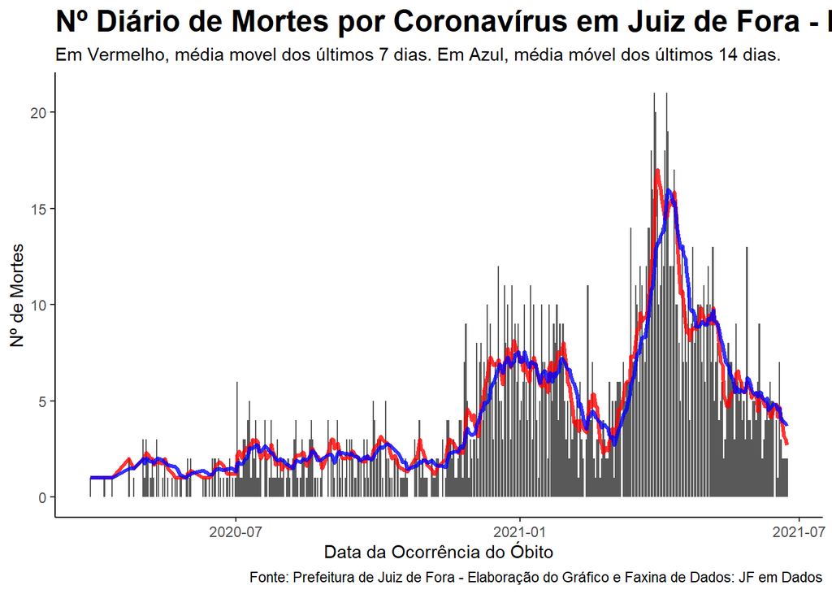

#### Número de Mortes Por Faixa Etária:

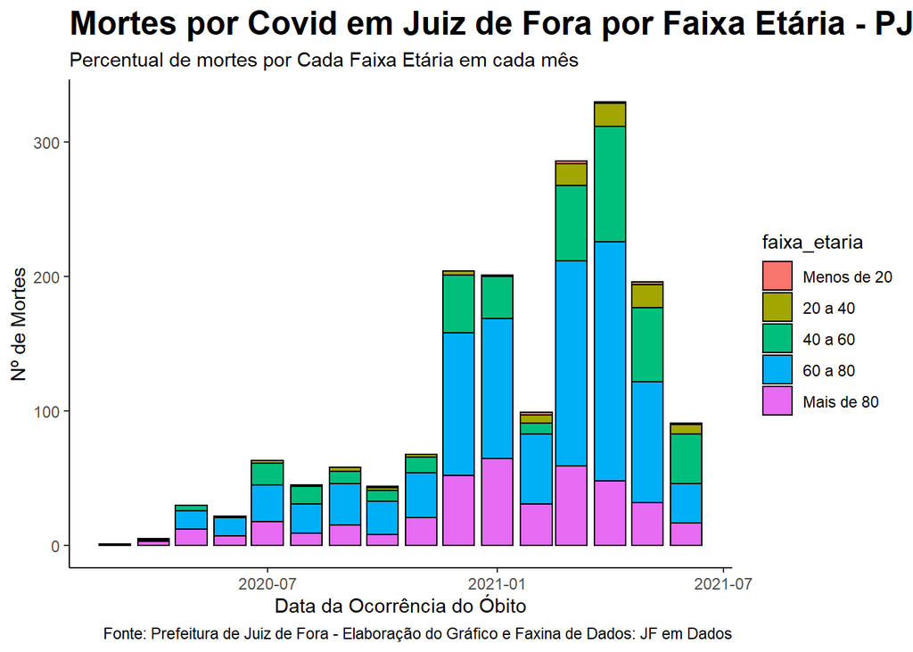

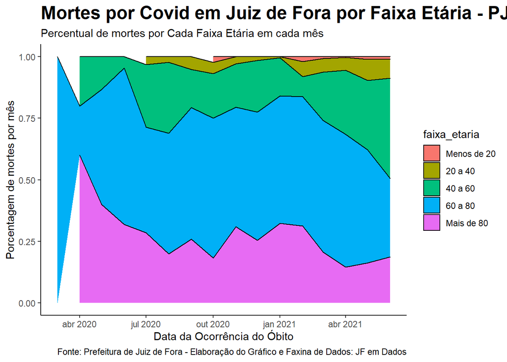

#### Obtendo nº de comorbidades

As comorbidades mais presentes. Alerta: O percentual é mais de 100%, porque quem tem mais de uma comorbidade conta mais de uma vez ao fazer o unnest().

```r
obitos_diarios_pjf_tidy_comorbidade_separado %>%
  count(comorbidades)%>%
  arrange(desc(n))%>%
  mutate(total= nrow(obitos_diarios_pjf_tidy),
         percentual = n/total) %>%
  as_tibble()
```

```
## # A tibble: 159 x 4
##    comorbidades                       n total percentual
##    <chr>                          <int> <int>      <dbl>
##  1 doença cardiovascular crônica    722  1743     0.414
##  2 hipertensão arterial sistêmica   711  1743     0.408
##  3 diabetes                         608  1743     0.349
##  4 obesidade                        255  1743     0.146
##  5 doença neurológica crônica       220  1743     0.126
##  6 sem comorbidade                  164  1743     0.0941
##  7 pneumopatia crônica              114  1743     0.0654
##  8 doença renal crônica             111  1743     0.0637
##  9 hipotireoidismo                   67  1743     0.0384
## 10 imunodeficiência                  42  1743     0.0241
## # ... with 149 more rows
```

Muito obrigado Curso-R, Bea, Fernando e Julio!